# Project_1

# Data Visualization On Speed Dating Dataset

## Dataset Introduction

Data was gathered from participants in experimental speed dating events from 2002-2004. The subjects were drawn from students in graduate and professional schools at Columbia University. Parcipants were recruited through a combination of mass e-mail and fliers posted throughout the campus and handed out by research assistants. During the events, the attendees would have a 4 minute “first date” with every other participant of the opposite sex. At the end of their 4 minutes, participants were asked if they would like to see their date again. They were also asked to rate their date on six attributes:

1. Attractiveness
2. Sincerity
3. Intelligence
4. Fun
5. Ambition
6. Shared Interests

The dataset also includes questionnaire data gathered from participants at different points in the process. These fields include: demographics, dating habits, self-perception across key attributes, belifs on what others find valuable in a mate, and ifestyle information.

## Data Description

```r
# Data reading in
setwd("~/Desktop/NYCDSA/Project/Project_1")
library(ggplot2)
library(scales)
library(reshape2)
library(dplyr)
library(ggthemes)
library(grid)
date <- read.csv("Speed Dating Data.csv",
                 sep = ',', stringsAsFactors = FALSE,
                 header = TRUE)
date1 <- date
dim(date1)
```

```
## [1] 8378  195
```

```r
colnames(date1)
```

```
##   [1] "iid"      "id"       "gender"   "idg"      "condtn"   "wave"
##   [7] "round"    "position" "positin1" "order"    "partner"  "pid"
##  [13] "match"    "int_corr" "samerace" "age_o"    "race_o"   "pf_o_att"
##  [19] "pf_o_sin" "pf_o_int" "pf_o_fun" "pf_o_amb" "pf_o_sha" "dec_o"
##  [25] "attr_o"   "sinc_o"   "intel_o"  "fun_o"    "amb_o"    "shar_o"
##  [31] "like_o"   "prob_o"   "met_o"    "age"      "field"    "field_cd"
##  [37] "undergra" "mn_sat"   "tuition"  "race"     "imprace"  "imprelig"
##  [43] "from"     "zipcode"  "income"   "goal"     "date"     "go_out"
##  [49] "career"   "career_c" "sports"   "tvsports" "exercise" "dining"
##  [55] "museums"  "art"      "hiking"   "gaming"   "clubbing" "reading"
##  [61] "tv"       "theater"  "movies"   "concerts" "music"    "shopping"
##  [67] "yoga"     "exphappy" "expnum"   "attr1_1"  "sinc1_1"  "intel1_1"
##  [73] "fun1_1"   "amb1_1"   "shar1_1"  "attr4_1"  "sinc4_1"  "intel4_1"
##  [79] "fun4_1"   "amb4_1"   "shar4_1"  "attr2_1"  "sinc2_1"  "intel2_1"
##  [85] "fun2_1"   "amb2_1"   "shar2_1"  "attr3_1"  "sinc3_1"  "fun3_1"
```

[output cut: 18 more lines]

The are 551 people participating in speed dating events, and unique IDs were assigned to these participants. The dataset has 8378 observations and 195 variables, recording all the information for every single dates.

The 195 variables could be divided into 5 categories, based on their backgrounds: a. Personal information b. Sports (17 var.) c. Partner’s information d. Scorecard (9 var.) e. Others

## Data Preprocessing

#### a. Select sunjects in waves without variation

A total of 21 sessions were ran, and 8 have been omitted because there were variations in these dating waves, that might influence people’s final decision.

Among these 13 waves, although 4 of them used different preference scale than the rest, they were included into our sample dataset in order to maintain the general information of the original dataset.

Waves 5, 12, 13, 14, 18, 19, 20 and 21 were omitted:

```r
date1 <- date1[!date1$wave %in% c(5, 12, 13, 14, 18, 19, 20, 21),]
date1$match <- as.factor(date1$match)
date1$gender <- as.factor(date1$gender)
nrow(date1)                    # 5322 obs
```

```
## [1] 5322
```

```r
length(unique(date1$iid))      # 348 individuals
```

```
## [1] 348
```

#### b. Re-scale scores of attributes

In wave 6-9, the preference scale for the 6 attributes ranges from 1-10, while in others the range is 0-100 for each single attribute, but with a sum socre of these 6 attributes equaling to 100. For the variables categorized as scorecard, the 6 attributes were recorded in scale of 1-10. Re-scaling is implemented so that comparison among different attributes would be more observable. Variables scaled from 1-10 were rescaled to 1-100 based on their weights in corresponding sum score of 6 attributes.

## Pre-Research Questions:

##### a. What are the least desirable attributes in a male partner? Does this differ for female partners?

##### b. Will being physically attractive help you get more dates?

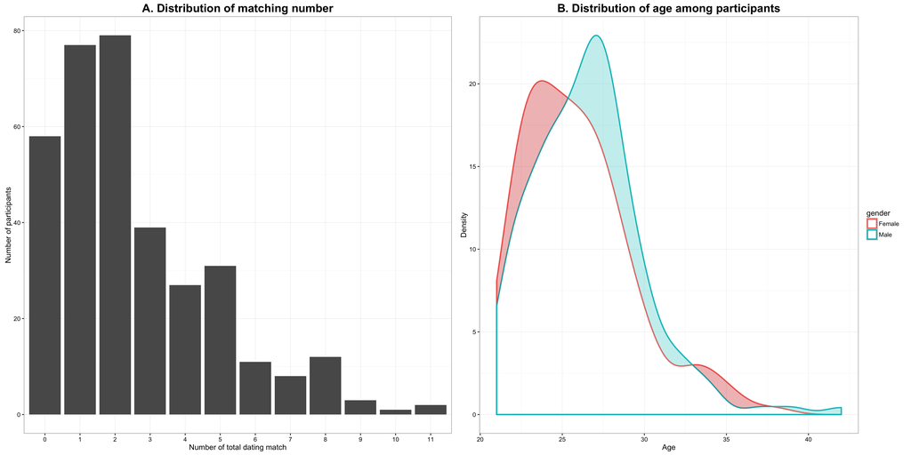

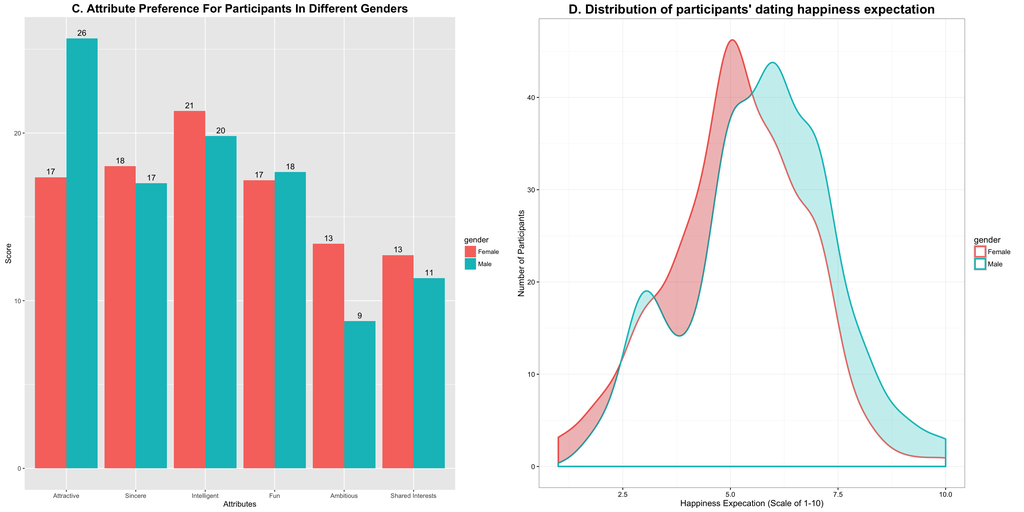

*Figure 1. Brief exploratory data analysis for chosen attributes based on the research questions*

- Observations from these plots:
  1. **Distribution of Number of Matches** *(Upper-Left)*
  - Around 60 participants received no dating match.
  2. **Density of Age** *(Upper-Right)*
  - The peak of the density plot for male participants located at the age greater than that for female participants.
  3. **Attributes’ Preferences** *(Bottom-Left)*
  - Female participants put greater weight on non-physical attributes, while male participants place more value on physical attractiveness.
  4. **Density of Happiness Expectation of Speed-Dating** *(Bottom-Right)*
  - Males might expect higher happiness for a date than females do.

## How were participants’ answer on same survey questions varying at different stage of dating?

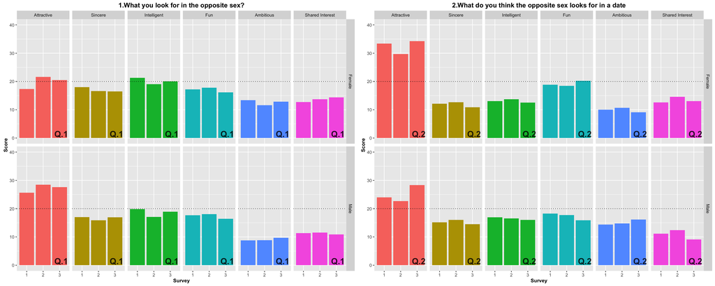

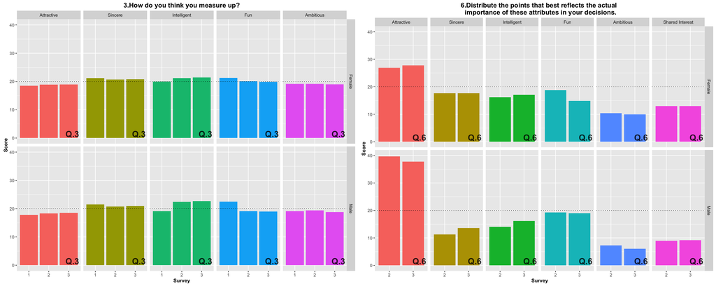

*Figure 2. The answers for question in the surveys. Surveys were taken at different stage of dating in chronological order.*

- Inferences:
  1. **What you look for in the opposite sex?**
  - Males weight more on physical attractiveness.
  - Females’ weight on different attributes are more balanced than males.
  2. **What do you think the opposite sex looks for in a date?**
  - Males think females would weight more on physical attractiveness than on other attributes.
  - Females think males would weight more on physical attractiveness than on other attribute.
  3. **How do you think you measure up?**
  - Males evaluate their attributes almost evenly.
  - Femals evaluate their attributes almost evenly.
  4. **Distribute the points that best reflects the actual importance of these attributes in your decisions.**
  - Males weight more on physical attractiveness than females do.
  - Females considers on physical attractiveness more than on any other attributes.

## Will being physically attractive help you get more dates?

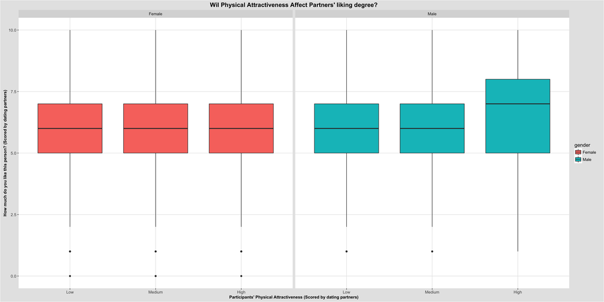

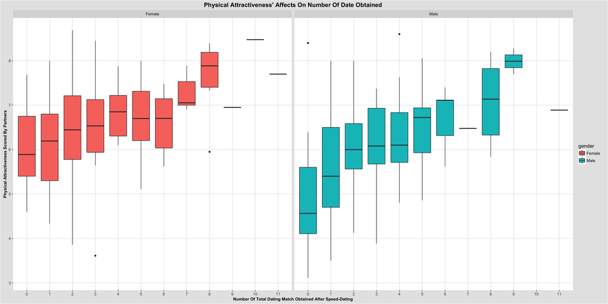

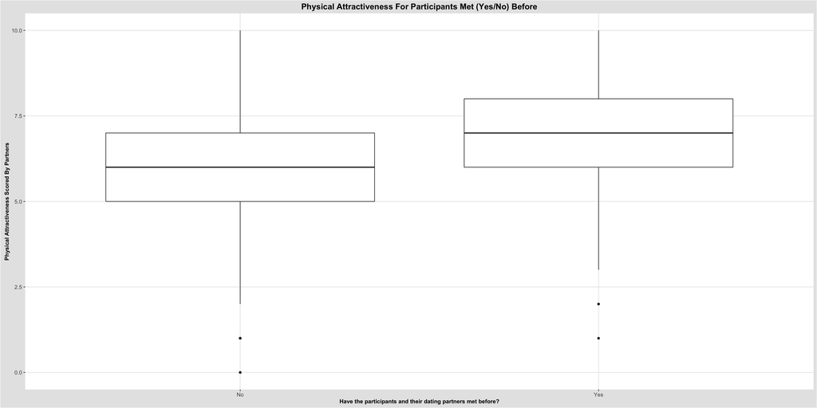

- Observations:
  - Males, with a high physical attractiveness, gained higher mean liking degree than males in other groups.
  - Females gained similar liking degree from their partners, despite the difference in physical attractiveness.
  - The sensitivity towards physical attractiveness of females is stronger than that of males.
  - The more the number of total match obtained, the higher the mean of participants’ physical attractiveness.
- Inferences:
1. Physical attractiveness is probably the most considered and valued attribute among those six attributes: attractiveness, sincerity, intelligence, fun, ambition, and shared interests.
2. Even though males valued physical attractiveness, females seem to have high sensitivity on this attribute than do males.
- Further Questions:
1. Are there any common attributes that can be found from participants received no dating match?
2. Is ambition another influencing attribute in speed-dating?
3. When choosing dating partner, how is age and race being weighted?
- Limitations:
1. The sample size is too small and the survey subjects were collected from Columbia University; therefore bias might be introduced.
2. The survey questions were not comprehensive.
3. Some key features of participants were not recorded. (i.e. number of ex-, length of the longest relationship they had, etc.)